# stats 506 hw3

Author

Chengrui Zhao

citation and github link will be written at the bottom

## Problem 1

This problem will require things have not covered. Use the R help, or online resources, to figure out the appropriate command(s). Use citation as necessary.

For the “nice tables”, use a package such as kable or stargazer (or find another package) to generate HTML/LaTeX tables for inclusion. The results should be clearly labeled, rounded appropriately, and easily readable.

a, Download the file VIX_D from this location, and determine how to read it into R. Then download the file DEMO_D from this location. Note that each page contains a link to a documentation file for that data set. Merge the two files to create a single data.frame, using the SEQN variable for merging. Keep only records which matched. Print out your total sample size, showing that it is now 6,980.

```r
#upload the package needed
library(foreign)
#read in files
vix<-read.xport("C:\\Users\\DELL\\Downloads\\VIX_D.XPT")
demod<-read.xport("C:\\Users\\DELL\\Downloads\\DEMO_D.XPT")

#combine all files
mer<-merge(vix,demod,by.x="SEQN",by.y="SEQN",all=F)

#get the number of data now
nrow(mer)
```

```
[1] 6980
```

Here I searched for how to open XPT files and the related citation link is written at the bottom of this file, I use merge to merge all files, and it turns out there exist 6980 rows of data.

b, Without fitting any models, estimate the proportion of respondents within each 10-year age bracket (e.g. 0-9, 10-19, 20-29, etc) who wear glasses/contact lenses for distance vision. Produce a nice table with the results.

```r
#upload the package needed
library(kableExtra)
#get all the proportions, here there do exist some NA data and to deal with it, I eliminate all of them while counting the sum, meanwhile make all number to the nearest three digits
proportion<-c(nrow(mer[which(mer$RIDAGEYR>=0 & mer$RIDAGEYR<=9 & mer$VIQ220==1),])/nrow(mer[which(mer$RIDAGEYR>=0 & mer$RIDAGEYR<=9 & is.na(mer$VIQ220)==F),]),round(nrow(mer[which(mer$RIDAGEYR>=10 & mer$RIDAGEYR<=19 & mer$VIQ220==1),])/nrow(mer[which(mer$RIDAGEYR>=10 & mer$RIDAGEYR<=19 & is.na(mer$VIQ220)==F),]),3),round(nrow(mer[which(mer$RIDAGEYR>=20 & mer$RIDAGEYR<=29 & mer$VIQ220==1),])/nrow(mer[which(mer$RIDAGEYR>=20 & mer$RIDAGEYR<=29 & is.na(mer$VIQ220)==F),]),3),round(nrow(mer[which(mer$RIDAGEYR>=30 & mer$RIDAGEYR<=39 & mer$VIQ220==1),])/nrow(mer[which(mer$RIDAGEYR>=30 & mer$RIDAGEYR<=39 & is.na(mer$VIQ220)==F),]),3),round(nrow(mer[which(mer$RIDAGEYR>=40 & mer$RIDAGEYR<=49 & mer$VIQ220==1),])/nrow(mer[which(mer$RIDAGEYR>=40 & mer$RIDAGEYR<=49 & is.na(mer$VIQ220)==F),]),3),round(nrow(mer[which(mer$RIDAGEYR>=50 & mer$RIDAGEYR<=59 & mer$VIQ220==1),])/nrow(mer[which(mer$RIDAGEYR>=50 & mer$RIDAGEYR<=59 & is.na(mer$VIQ220)==F),]),3),round(nrow(mer[which(mer$RIDAGEYR>=60 & mer$RIDAGEYR<=69 & mer$VIQ220==1),])/nrow(mer[which(mer$RIDAGEYR>=60 & mer$RIDAGEYR<=69 & is.na(mer$VIQ220)==F),]),3),round(nrow(mer[which(mer$RIDAGEYR>=70 & mer$RIDAGEYR<=79 & mer$VIQ220==1),])/nrow(mer[which(mer$RIDAGEYR>=70 & mer$RIDAGEYR<=79 & is.na(mer$VIQ220)==F),]),3),round(nrow(mer[which(mer$RIDAGEYR>=80 & mer$RIDAGEYR<=89 & mer$VIQ220==1),])/nrow(mer[which(mer$RIDAGEYR>=80 & mer$RIDAGEYR<=89 & is.na(mer$VIQ220)==F),]),3))

#give kable better rownames
Age_Group<- c("0~9","10~19","20~29","30~39","40~49","50~59","60~69","70~79","80~89")

kab<-cbind(Age_Group,proportion)

#due to no valid data in 0~9, the proportion here is NA, change it to 0
kab[1,2]<-0

#get kable
knitr::kable(kab)
```

| Age_Group | proportion |
| --- | --- |
| 0~9 | 0 |
| 10~19 | 0.321 |
| 20~29 | 0.326 |
| 30~39 | 0.359 |
| 40~49 | 0.37 |
| 50~59 | 0.55 |
| 60~69 | 0.622 |
| 70~79 | 0.669 |
| 80~89 | 0.669 |

Here I get the proportion of wearing glasses for distant in all age group, and use kable to make a nicer table.

c, Fit three logistic regression models predicting whether a respondent wears glasses/contact lenses for distance vision. Predictors:

age

age, race, gender

age, race, gender, Poverty Income ratio

Produce a table presenting the estimated odds ratios for the coefficients in each model, along with the sample size for the model, the pseudo-R^2 , and AIC values.

```r
#Since there exist NA in response, eliminate them first
mer<-mer[which(is.na(mer$VIQ220)==F),]
mer<-mer[which(is.na(mer$RIDAGEYR)==F),]
mer<-mer[which(is.na(mer$RIAGENDR)==F),]
mer<-mer[which(is.na(mer$RIDRETH1)==F),]
mer<-mer[which(is.na(mer$INDFMPIR)==F),]

#eliminate those unknown data
mer<-mer[which(mer$VIQ220!=9),]

#change data into factor so that logistic model can be conducted
mer$VIQ220<-as.factor(mer$VIQ220)
mer$RIAGENDR<-as.factor(mer$RIAGENDR)
mer$RIDRETH1<-as.factor(mer$RIDRETH1)

#use glm models to get result of first model
fit1<-glm(mer$VIQ220~mer$RIDAGEYR,family=binomial(link="logit"))
summary(fit1)
```

```
Call:
glm(formula = mer$VIQ220 ~ mer$RIDAGEYR, family = binomial(link = "logit"))

Deviance Residuals:
    Min       1Q   Median       3Q      Max
-1.5927  -1.1746   0.8296   0.9823   1.5440

Coefficients:
             Estimate Std. Error z value Pr(>|z|)
(Intercept)   1.22877    0.05464   22.49   <2e-16 ***
mer$RIDAGEYR -0.02422    0.00124  -19.54   <2e-16 ***
---
Signif. codes:  0 '***' 0.001 '**' 0.01 '*' 0.05 '.' 0.1 ' ' 1

(Dispersion parameter for binomial family taken to be 1)

    Null deviance: 8519.1  on 6246  degrees of freedom
Residual deviance: 8115.9  on 6245  degrees of freedom
AIC: 8119.9

Number of Fisher Scoring iterations: 4
```

```r
#to get the result clearer, conduct kable again for the first model
kab1<-rbind(cbind(exp(coef(fit1))),"sample size"=nobs(fit1),"pseudo-R^2"=1-fit1$deviance/fit1$null.deviance,"AIC"=fit1$aic)
knitr::kable(kab1)
```

| (Intercept) | 3.4170427 |
| --- | --- |
| mer$RIDAGEYR | 0.9760682 |
| sample size | 6247.0000000 |
| pseudo-R^2 | 0.0473330 |
| AIC | 8119.8714676 |

```r
#use glm models to get result of second model
fit2<-glm(mer$VIQ220~mer$RIDAGEYR+mer$RIDRETH1+mer$RIAGENDR,family=binomial(link="logit"))
summary(fit2)
```

```
Call:
glm(formula = mer$VIQ220 ~ mer$RIDAGEYR + mer$RIDRETH1 + mer$RIAGENDR,
    family = binomial(link = "logit"))

Deviance Residuals:
    Min       1Q   Median       3Q      Max
-1.8590  -1.1507   0.7299   1.0066   1.7283

Coefficients:
               Estimate Std. Error z value Pr(>|z|)
(Intercept)    1.800407   0.080163  22.459  < 2e-16 ***
mer$RIDAGEYR  -0.022335   0.001295 -17.249  < 2e-16 ***
mer$RIDRETH12 -0.155477   0.167518  -0.928  0.35335
mer$RIDRETH13 -0.639113   0.071953  -8.882  < 2e-16 ***
mer$RIDRETH14 -0.256501   0.078519  -3.267  0.00109 **
mer$RIDRETH15 -0.632805   0.138601  -4.566 4.98e-06 ***
mer$RIAGENDR2 -0.502003   0.054054  -9.287  < 2e-16 ***
---
Signif. codes:  0 '***' 0.001 '**' 0.01 '*' 0.05 '.' 0.1 ' ' 1

(Dispersion parameter for binomial family taken to be 1)

    Null deviance: 8519.1  on 6246  degrees of freedom
Residual deviance: 7935.1  on 6240  degrees of freedom
AIC: 7949.1

Number of Fisher Scoring iterations: 4
```

```r
#to get the result clearer, conduct table again for the second model
kab2<-rbind(cbind(exp(coef(fit2))),"sample size"=nobs(fit2),"pseudo-R^2"=1-fit2$deviance/fit2$null.deviance,"AIC"=fit2$aic)
knitr::kable(kab2,"simple")
```

| (Intercept) | 6.0521094 |
| --- | --- |
| mer$RIDAGEYR | 0.9779121 |
| mer$RIDRETH12 | 0.8560069 |
| mer$RIDRETH13 | 0.5277604 |
| mer$RIDRETH14 | 0.7737545 |
| mer$RIDRETH15 | 0.5310998 |
| mer$RIAGENDR2 | 0.6053170 |
| sample size | 6247.0000000 |
| pseudo-R^2 | 0.0685555 |
| AIC | 7949.0753329 |

```r
#use glm models to get result of third model
fit3<-glm(mer$VIQ220~mer$RIDAGEYR+mer$RIDRETH1+mer$RIAGENDR+mer$INDFMPIR,family=binomial(link="logit"))
summary(fit3)
```

```
Call:
glm(formula = mer$VIQ220 ~ mer$RIDAGEYR + mer$RIDRETH1 + mer$RIAGENDR +
    mer$INDFMPIR, family = binomial(link = "logit"))

Deviance Residuals:
    Min       1Q   Median       3Q      Max
-1.9347  -1.1207   0.7183   0.9890   1.8388

Coefficients:
               Estimate Std. Error z value Pr(>|z|)
(Intercept)    2.016160   0.087788  22.966  < 2e-16 ***
mer$RIDAGEYR  -0.022188   0.001295 -17.135  < 2e-16 ***
mer$RIDRETH12 -0.116023   0.168265  -0.690 0.490495
mer$RIDRETH13 -0.501529   0.075149  -6.674 2.49e-11 ***
mer$RIDRETH14 -0.207385   0.079217  -2.618 0.008847 **
mer$RIDRETH15 -0.532727   0.140152  -3.801 0.000144 ***
mer$RIAGENDR2 -0.516271   0.054305  -9.507  < 2e-16 ***
mer$INDFMPIR  -0.113598   0.017707  -6.415 1.41e-10 ***
---
Signif. codes:  0 '***' 0.001 '**' 0.01 '*' 0.05 '.' 0.1 ' ' 1

(Dispersion parameter for binomial family taken to be 1)

    Null deviance: 8519.1  on 6246  degrees of freedom
Residual deviance: 7893.8  on 6239  degrees of freedom
AIC: 7909.8

Number of Fisher Scoring iterations: 4
```

```r
#to get the result clearer, conduct kable again for the third model
kab3<-rbind(cbind(exp(coef(fit3))),"sample size"=nobs(fit3),"pseudo-R^2"=1-fit3$deviance/fit3$null.deviance,"AIC"=fit3$aic)
knitr::kable(kab3,"simple")
```

| (Intercept) | 7.5094311 |
| --- | --- |
| mer$RIDAGEYR | 0.9780560 |
| mer$RIDRETH12 | 0.8904552 |
| mer$RIDRETH13 | 0.6056040 |
| mer$RIDRETH14 | 0.8127071 |
| mer$RIDRETH15 | 0.5870020 |
| mer$RIAGENDR2 | 0.5967415 |
| mer$INDFMPIR | 0.8926169 |
| sample size | 6247.0000000 |
| pseudo-R^2 | 0.0733995 |
| AIC | 7909.8082208 |

Here use GLM to produce logistics models with binary distribution according to information from question. For the first model with age as predictor, odds ratio of age is around e^(-0.024)=0.976, sample size=6246+1=6247,pseudo-R^2=1-8115.9/8519.1=0.047, indicating that it doesn’t fit well, AIC=8119.9

The second one use age, race and gender as predictor, Since race and gender is also categorical, I view them as factors here too. odds ratio of age is e^(-0.022)=0.978, race: other hispanic e^(-0.155)=0.856, non-hispanic white e^(-0.639)=0.528, non-hispanic black e^(-0.257)=0.773, other race e^(-0.633)=0.531, gender: female e^(-0.502)=0.605, sample size=6246+1=6247, pseudo-R^2=1-7935.1/8519.1=0.069, still not a good fit, AIC=7949.1, indicating that it’s better than the first model.

The third one uses age, race, gender and poverty income ratio as predictor, odds ratio of age is e^(-0.022)=0.978, race: other hispanic e^(-0.116)=0.89, non-hispanic white e^(-0.502)=0.606, non-hispanic black e^(-0.207)=0.813, other race e^(-0.533)=0.587, gender: female e^(-0.516)=0.597, poverty income ratio e^(-0.114)=0.893. sample size=6246+1=6247, pseudo-R^2=1-7893.8/8519.1=0.073, still not big, AIC=7909.8, indicating it’s the most suitable model of three.

d, From the third model from the previous part, test whether the odds of men and women being wears of glasess/contact lenses for distance vision differs. Test whether the proportion of wearers of glasses/contact lenses for distance vision differs between men and women. Include the results of the each test and their interpretation.

```r
#use glm models to get result of third model
fit3<-glm(mer$VIQ220~mer$RIDAGEYR+mer$RIDRETH1+mer$RIAGENDR+mer$INDFMPIR,family=binomial(link="logit"))
summary(fit3)
```

```
Call:
glm(formula = mer$VIQ220 ~ mer$RIDAGEYR + mer$RIDRETH1 + mer$RIAGENDR +
    mer$INDFMPIR, family = binomial(link = "logit"))

Deviance Residuals:
    Min       1Q   Median       3Q      Max
-1.9347  -1.1207   0.7183   0.9890   1.8388

Coefficients:
               Estimate Std. Error z value Pr(>|z|)
(Intercept)    2.016160   0.087788  22.966  < 2e-16 ***
mer$RIDAGEYR  -0.022188   0.001295 -17.135  < 2e-16 ***
mer$RIDRETH12 -0.116023   0.168265  -0.690 0.490495
mer$RIDRETH13 -0.501529   0.075149  -6.674 2.49e-11 ***
mer$RIDRETH14 -0.207385   0.079217  -2.618 0.008847 **
mer$RIDRETH15 -0.532727   0.140152  -3.801 0.000144 ***
mer$RIAGENDR2 -0.516271   0.054305  -9.507  < 2e-16 ***
mer$INDFMPIR  -0.113598   0.017707  -6.415 1.41e-10 ***
---
Signif. codes:  0 '***' 0.001 '**' 0.01 '*' 0.05 '.' 0.1 ' ' 1

(Dispersion parameter for binomial family taken to be 1)

    Null deviance: 8519.1  on 6246  degrees of freedom
Residual deviance: 7893.8  on 6239  degrees of freedom
AIC: 7909.8

Number of Fisher Scoring iterations: 4
```

from c and the third model again here we can see the p-value for gender is less than 0.05, indicating that there do exist a difference between the glasses wearing for distant vision between men and women, the related coefficient is -0.516, e^(-0.516)=0.597,0.597/(1-0.597)=1.481,so the odds of women wearing glasses is 1.481 times the odds of men wearing glasses.

```r
#get the table of men wearing glasses, men not wearing, women wearing glasses, women not wearing
tab<-table(mer$VIQ220,mer$RIAGENDR)

#use variables to represent these numbers
menno<-tab[2,1]
menyes<-tab[1,1]
womenno<-tab[2,2]
womenyes<-tab[1,2]

#get the total number of men and women
men<-menno+menyes
women<-womenno+womenyes

#conduct 2-sample test to get answer
proportion2<-prop.test(c(menyes,womenyes),c(men,women))
proportion2
```

```
    2-sample test for equality of proportions with continuity correction

data:  c(menyes, womenyes) out of c(men, women)
X-squared = 69.683, df = 1, p-value < 2.2e-16
alternative hypothesis: two.sided
95 percent confidence interval:
 -0.12945505 -0.08007986
sample estimates:
   prop 1    prop 2
0.3714379 0.4762054
```

here compare the proportion of men and women wearing glasses, p-value<0.05 indicates that there do exist a significant differences between proportion of men and women wearing glasses, the proportion of men wearing glasses is 0.371 and for women is 0.476.

## problem 2

a, What year is the oldest movie from, and how many movies were released in that year? Answer this with a single SQL query.

```r
#upload packages needed
library(DBI)
library(RSQLite)
#get the file
sakila<-dbConnect(SQLite(), "C:\\Users\\DELL\\Downloads\\sakila_master.db")

#get all the oldest films and the year
dbGetQuery(sakila,"
           SELECT COUNT(title),release_year
           FROM film
           ORDER BY release_year
           LIMIT 1
           ")
```

```
  COUNT(title) release_year
1         1000         2006
```

here first get the package needed and select the suitable file from it, then get the answer by selecting films from the minimum release year, the oldest film is from 2006 and there are 1000 of them.

b, What genre of movie is the least common in the data, and how many movies are of this genre?

```r
#method 1
#get the things needed to build data frame from category
category<-dbGetQuery(sakila,"
                 SELECT name,category_id
                 FROM category
                 ")

#get the things needed to build data frame from film_category
number<-dbGetQuery(sakila,"
                 SELECT category_id
                 FROM film_category
                 ")

#build the table to see how many films are there in each genre
tabforfilm<-table(number)

#get the genre with minimum number of film
filmmin<-which.min(tabforfilm)

#build the data frame with the category name corresponding to the category id and the number of films in it
data.frame(cbind(category[which(category$category_id==filmmin),1],tabforfilm[filmmin]))
```

```
      X1 X2
12 Music 51
```

```r
#method 2
#directly get the least number of film in a film type with one query
dbGetQuery(sakila,"
                             SELECT category.name,COUNT(film_category.film_id)
                             FROM category
                                  INNER JOIN film_category on category.category_id=film_category.category_id
                             GROUP BY category.name
                             ORDER BY COUNT(film_category.film_id) ASC
                             LIMIT 1
                             ")
```

```
   name COUNT(film_category.film_id)
1 Music                           51
```

This question is solved by two ways, first one is to get the things needed from two files respectively, then get the genre with least films by table, finally build the data frame based on the two data frames obtained from two files and table, the second method also involves using SQL to the two files involved, but meanwhile since we use SQL to get the answer directly, we can just use inner join to combine two data frames together and get what I want without building tables. use order by to make the category with least the first one and then limit to it. so the genre is Music with 51 film.

c, Identify which country or countries have exactly 13 customers

```r
#method 1
#get the data frame of countries and number of customers in it
con<-as.data.frame(dbGetQuery(sakila,"
                               SELECT COUNT(ID), country
                               FROM customer_list
                               GROUP BY country
                               "))

#get which country has 13 customers
con[which(con$`COUNT(ID)`==13),]
```

```
   COUNT(ID)   country
6         13 Argentina
68        13   Nigeria
```

```r
#method 2
#directly get country with 13 customers with one query
dbGetQuery(sakila,"
                               SELECT COUNT(ID), country
                               FROM customer_list
                               GROUP BY country
                               HAVING COUNT(ID)==13
                               ")
```

```
  COUNT(ID)   country
1        13 Argentina
2        13   Nigeria
```

This question is solved with two methods, first one is to get data frame of different countries and corresponding number of customers, then select the row with 13 customers. The second method also involves getting data frame of different countries and corresponding number of customers, but here directly get the country with 13 customers with having function in SQL. It turns out Argentina and Nigeria has 13 customers

## Problem 3

a, What proportion of email addresses are hosted at a domain with TLD “.com”? (in the email, “angrycat@freemail.org”, “freemail.org” is the domain, and “.org” is the TLD (top-level domain).)

```r
#read in the file
rec<-read.csv("C:\\Users\\DELL\\Downloads\\us-500\\us-500.csv")

#get the number of residents with .com end in email
rec1<-rec[grep(".com$",rec[,ncol(rec)-1]),]

#get the proportion
nrow(rec1)/nrow(rec)
```

```
[1] 0.732
```

here use regular expression to get the rows with email end in .com and conduct the calculation, the proportion is 0.732

b, What proportion of email addresses have at least one non alphanumeric character in them? (Excluding the required “@” and “.” found in every email address.)

```r
#upload the package needed
library(stringr)
#get all email address
rec2<-rec[,ncol(rec)-1]

#eliminate all alphanumeric character for following analysis
rec2<-str_replace_all(rec2,"[[:alnum:]]","")

#since the regular @ and . are eliminated, we need to find those beyond @.
j<-0
for(i in 1:length(rec2)){
  if(rec2[i]!="@."){
    j<-j+1
  }
}

#get the proportion
j/length(rec2)
```

```
[1] 0.506
```

here first eliminate all alphanumeric character in email so that for normal email only “@.”(since in domain and TLD there are no extra special character), then get the proportion of email that’s not “@.” currently. The proportion is 0.506

c, What are the top 5 most common area codes amongst all phone numbers? (The area code is the first three digits of a standard 10-digit telephone number.)

```r
#get the phone number 2
rec3<-rec[,ncol(rec)-2]

#get the phone number 1
rec4<-rec[,ncol(rec)-3]

#subtract both to their area code
for(i in 1:length(rec3)){
  rec3[i]<-substr(rec3[i],1,3)
}
for(i in 1:length(rec3)){
  rec4[i]<-substr(rec4[i],1,3)
}

#test whether two area codes are the same, and it turns out they are the same
for(i in 1:length(rec3)){
  if(rec3[i]!=rec4[i]){
    print(F)
    break
  }
}

#use table to get the answer
sor<-sort(table(rec3),decreasing=T)
head(sor,5)
```

```
rec3
973 212 215 410 201
 18  14  14  14  12
```

here we have two column of phone number, so the first thing is to subtract area code to see whether they are the same, it turns out that they are the same so now just see the table of one column of phone number and see its code, it turns out that 973, 410, 215, 212 and 201 are the most common.

d, Produce a histogram of the log of the apartment numbers for all addresses. (You may assume any number at the end of the an address is an apartment number.)

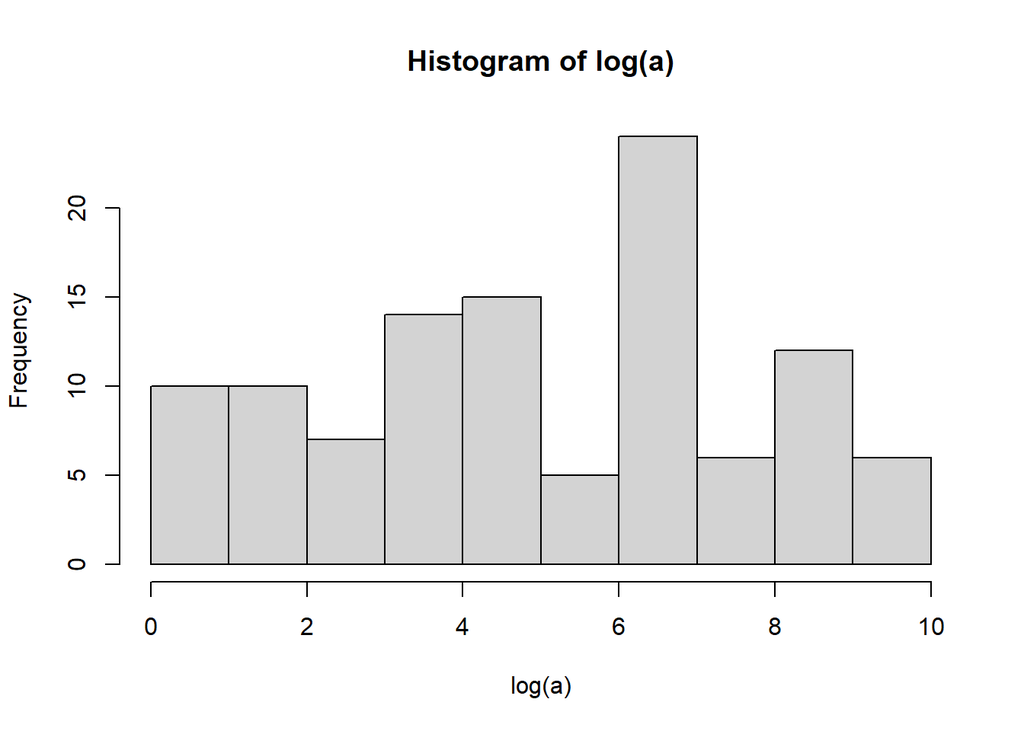

```r
#get the address
rec5<-rec[,4]

#get those address with an apartment number
rec5<-rec5[grep("#",rec5)]

#get those apartment number
der<-c()
a<-c()
for(i in 1:length(rec5)){
  der[i]<-gregexpr("#",rec5[i])[[1]][1]
  a[i]<-substr(rec5[i],der[i]+1,nchar(rec5[i]))
}

#turn them into number so that we can draw histogram
a<-as.numeric(a)

#draw histogram
hist(log(a))
```

here since not all address has apartment number and some of them has number at the end but that’s the number of corresponding road not the apartment number, I first get the address with the “#” and subtract the number after it which are are apartment numbers, then use them to draw the histogram

e, Benford’s law is an observation about the distribution of the leading digit of real numerical data. Examine whether the apartment numbers appear to follow Benford’s law. Do you think the apartment numbers would pass as real data?

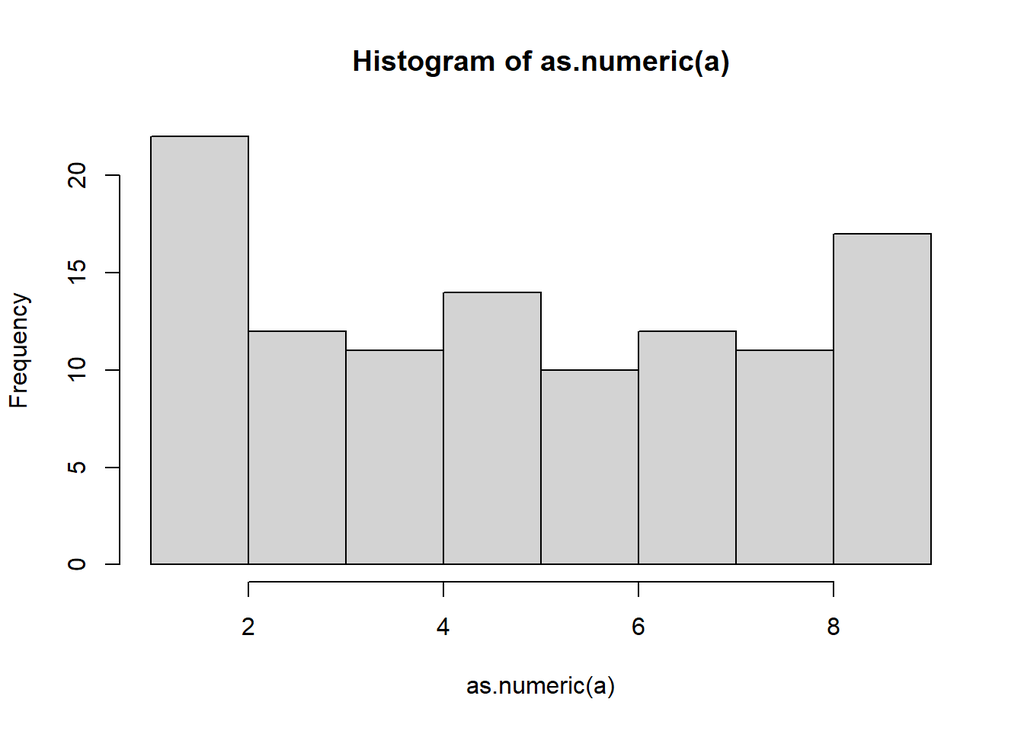

```r
#since this law is about the leading digit, subtract the leading digit
for(i in 1:length(a)){
  a[i]<-substr(a[i],1,1)
}

#draw relevant histogram
hist(as.numeric(a))
```

Here I first get all leading digits, if it satisfies Benford’s Law, then it will be a decreasing trend with number as 1 really high and 9 really low. However, here both 1 and 9 are high and others are relatively low, so it diesn’t satisfy Benford’s Law.

Citation: https://www.ms.uky.edu/~mai/splus/MoveDataFromSAStoR.html (link for how to open xpt)

Github link: